# MA_Project1

Pia Chouaifaty

10/12/2020

# Project Description

### Epithelial-mesenchymal status renders differential responses to cisplatin in ovarian cancer

The data set used is from a paper studying the differences in gene expression in mesenchymal and epithelial cells following cisplatin treatment. 171 samples of various cell lines treated with cisplatin and negative controls were obtained. The aim is to analyze differential expression as a response to cisplatin treatment between mesenchymal and epithelial cells.

Citation:  
Miow, Q., Tan, T., Ye, J. et al. Epithelial–mesenchymal status renders differential responses to cisplatin in ovarian cancer. Oncogene 34, 1899–1907 (2015). https://doi.org/10.1038/onc.2014.136

#Pipeline

## 1 Libraries

```r
#General Bioconductor packages
library(Biobase)
library(oligoClasses)

#Annotation and data import packages
library(ArrayExpress)
library(pd.hugene.1.0.st.v1)
library(hugene10sttranscriptcluster.db)

#Quality control and pre-processing packages
library(oligo)
library(arrayQualityMetrics)

#Analysis and statistics packages
library(limma)
library(topGO)
library(ReactomePA)
library(clusterProfiler)

#Plotting and color options packages
library(gplots)
library(ggplot2)
library(geneplotter)
library(RColorBrewer)
library(pheatmap)

#Formatting/documentation packages
   #library(rmarkdown)
   #library(BiocStyle)
library(dplyr)
library(tidyr)

#Helpers:
library(stringr)
library(matrixStats)
library(genefilter)
library(openxlsx)
   #library(devtools)
```

## 2 Downloading the Raw & Processed Data From Array Express

[ArrayExpress Experiment Link](https://www.ebi.ac.uk/arrayexpress/experiments/E-GEOD-47856/)  
Accession number: E-GEOD-47856

```r
raw_data_dir = "/Users/piachouaifaty/bif425_fall20_chouaifaty_pia_copy/MA_Pipeline_Project1/raw_data_files"
if(!dir.exists(raw_data_dir)) {dir.create(raw_data_dir)}

#anno_AE = getAE("E-GEOD-47856", path=raw_data_dir, type="raw")
```

```r
processed_data_dir = "/Users/piachouaifaty/bif425_fall20_chouaifaty_pia_copy/MA_Pipeline_Project1/processed_data"
if(!dir.exists(processed_data_dir)) {dir.create(processed_data_dir)}

#anno_AE = getAE("E-GEOD-47856", path=processed_data_dir, type="processed")
```

```r
sdrf_location = file.path(raw_data_dir, "E-GEOD-47856.sdrf.txt")
SDRF = read.delim(sdrf_location)
rownames(SDRF) = SDRF$Array.Data.File
```

## 3 Appending EMT Classification to SDRF

The authors supplied a list of cell lines that they found to be epithelial-like/mesenchymal-like in an additional experiment in the supplementary material.  
In order to make it easier to separate based on cell line EMT status (mesenchymal vs epithelial) later on, I add a column to the SDRF matrix specifying EMT status before transforming it into an annotated data frame.

The sample_classification.xls file was extracted from the supplementary data provided by the paper. sample_class is a dataframe containing the sample cell line and its classification as either epithelial-like or mesenchymal-like.

```r
#install.packages("readxl")
library(readxl)

suppl_dir = "/Users/piachouaifaty/bif425_fall20_chouaifaty_pia_copy/MA_Pipeline_Project1"
EMT_location = file.path(suppl_dir, "sample_classification.xls")
EMT_status = read_excel(EMT_location)
```

I now add the Classification column to the SDRF data frame.

```r
SDRF = left_join(SDRF, EMT_status, by = c("FactorValue..CELL.LINE." = "Sample"))
rownames(SDRF) = SDRF$Array.Data.File
SDRF2 = SDRF #for reference
rownames(SDRF2) = SDRF2$Array.Data.File
SDRF = AnnotatedDataFrame(SDRF)
```

Creating an ExpressionSet for the raw data

```r
raw_data = oligo::read.celfiles(filenames = file.path(raw_data_dir, SDRF$Array.Data.File), verbose = FALSE, phenoData = SDRF)
```

[output not shown]

[output cut: 116 more lines]

[output not shown]

```r
stopifnot(validObject(raw_data))
```

Taking a look at the raw data

```r
head(Biobase::pData(raw_data))
```

```
##                         Source.Name
## GSM1160893_SMhu186.CEL GSM1160893 1
## GSM1160892_SMhu185.CEL GSM1160892 1
## GSM1160891_SMhu184.CEL GSM1160891 1
## GSM1160890_SMhu183.CEL GSM1160890 1
## GSM1160889_SMhu182.CEL GSM1160889 1
## GSM1160888_SMhu181.CEL GSM1160888 1
##                                                                Comment..Sample_description.
## GSM1160893_SMhu186.CEL SMhu186 Gene expression data from cultured ovarian cancer cell line.
## GSM1160892_SMhu185.CEL SMhu185 Gene expression data from cultured ovarian cancer cell line.
## GSM1160891_SMhu184.CEL SMhu184 Gene expression data from cultured ovarian cancer cell line.
## GSM1160890_SMhu183.CEL SMhu183 Gene expression data from cultured ovarian cancer cell line.
## GSM1160889_SMhu182.CEL SMhu182 Gene expression data from cultured ovarian cancer cell line.
## GSM1160888_SMhu181.CEL SMhu181 Gene expression data from cultured ovarian cancer cell line.
##                                                         Comment..Sample_source_name.
## GSM1160893_SMhu186.CEL Cultured ovarian cancer cell line UWB1.289, Cisplatin treated
## GSM1160892_SMhu185.CEL         Cultured ovarian cancer cell line UWB1.289, untreated
## GSM1160891_SMhu184.CEL  Cultured ovarian cancer cell line TOV-21G, Cisplatin treated
## GSM1160890_SMhu183.CEL          Cultured ovarian cancer cell line TOV-21G, untreated
## GSM1160889_SMhu182.CEL Cultured ovarian cancer cell line TOV-112D, Cisplatin treated
## GSM1160888_SMhu181.CEL         Cultured ovarian cancer cell line TOV-112D, untreated
##                        Comment..Sample_title. Characteristics..batch.
## GSM1160893_SMhu186.CEL            UWB1.289(+)                       5
## GSM1160892_SMhu185.CEL            UWB1.289(-)                       5
## GSM1160891_SMhu184.CEL             TOV-21G(+)                       5
## GSM1160890_SMhu183.CEL             TOV-21G(-)                       5
## GSM1160889_SMhu182.CEL            TOV-112D(+)                       5
## GSM1160888_SMhu181.CEL            TOV-112D(-)                       5
##                        Characteristics..cell.line. Term.Source.REF
## GSM1160893_SMhu186.CEL                    UWB1.289
## GSM1160892_SMhu185.CEL                    UWB1.289
## GSM1160891_SMhu184.CEL                     TOV-21G
## GSM1160890_SMhu183.CEL                     TOV-21G
## GSM1160889_SMhu182.CEL                    TOV-112D             EFO
## GSM1160888_SMhu181.CEL                    TOV-112D             EFO
##                        Term.Accession.Number Characteristics..cell.type.
## GSM1160893_SMhu186.CEL                         ovarian cancer cell lines
## GSM1160892_SMhu185.CEL                         ovarian cancer cell lines
## GSM1160891_SMhu184.CEL                         ovarian cancer cell lines
## GSM1160890_SMhu183.CEL                         ovarian cancer cell lines
```

[output cut: 120 more lines]

```
## GSM1160888_SMhu181.CEL                    none
##                                           Term.Accession.Number.4
## GSM1160893_SMhu186.CEL http://purl.obolibrary.org/obo/CHEBI_27899
## GSM1160892_SMhu185.CEL
## GSM1160891_SMhu184.CEL http://purl.obolibrary.org/obo/CHEBI_27899
## GSM1160890_SMhu183.CEL
## GSM1160889_SMhu182.CEL http://purl.obolibrary.org/obo/CHEBI_27899
## GSM1160888_SMhu181.CEL
##                          Classification
## GSM1160893_SMhu186.CEL  Epithelial-like
## GSM1160892_SMhu185.CEL  Epithelial-like
## GSM1160891_SMhu184.CEL Mesenchymal-like
## GSM1160890_SMhu183.CEL Mesenchymal-like
## GSM1160889_SMhu182.CEL Mesenchymal-like
## GSM1160888_SMhu181.CEL Mesenchymal-like
```

Retain only columns that we need:  
1. Sample identifier (Source.Name)  
2. Treatment or control (FactorValue..TREATMENT)  
3. Cell line name (FactorValue..CELL.LINE.) 4. Cell line EMT classification (Classification)

```r
Biobase::pData(raw_data) = Biobase::pData(raw_data)[,c("Source.Name", "FactorValue..TREATMENT.", "FactorValue..CELL.LINE.", "Classification")]
SDRF2 = SDRF2[,c("Source.Name", "FactorValue..TREATMENT.", "FactorValue..CELL.LINE.","Classification")]

#head(Biobase::pData(raw_data))
```

## 4 Log-Transformation & Visualization

We take the log2 of the data, and plot the PCA to check if we have clustering based on cell line classification and/or treatment (cisplatin vs control).

```r
exp_raw = log2(Biobase::exprs(raw_data))
```

PCA Analysis & Plot

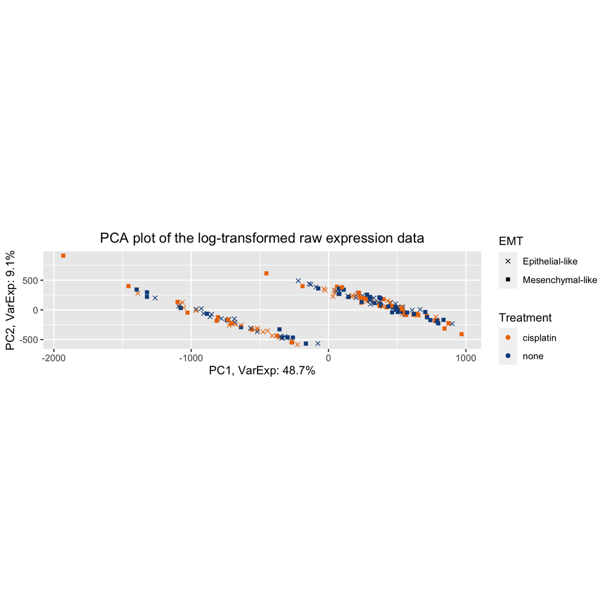

```r
PCA_raw <- prcomp(t(exp_raw), scale. = FALSE)

percentVar <- round(100*PCA_raw$sdev^2/sum(PCA_raw$sdev^2),1)
sd_ratio <- sqrt(percentVar[2] / percentVar[1])

dataGG <- data.frame(PC1 = PCA_raw$x[,1], PC2 = PCA_raw$x[,2],
                    EMT = pData(raw_data)$Classification,
                    Treatment = pData(raw_data)$FactorValue..TREATMENT.,
                    Source = pData(raw_data)$Source.Name)

ggplot(dataGG, aes(PC1, PC2)) +
      geom_point(aes(shape = EMT, colour = Treatment)) +
  ggtitle("PCA plot of the log-transformed raw expression data") +
  xlab(paste0("PC1, VarExp: ", percentVar[1], "%")) +
  ylab(paste0("PC2, VarExp: ", percentVar[2], "%")) +
  theme(plot.title = element_text(hjust = 0.5))+
  coord_fixed(ratio = sd_ratio) +
  scale_shape_manual(values = c(4,15)) +
  scale_color_manual(values = c("darkorange2", "dodgerblue4"))
```

Boxplot

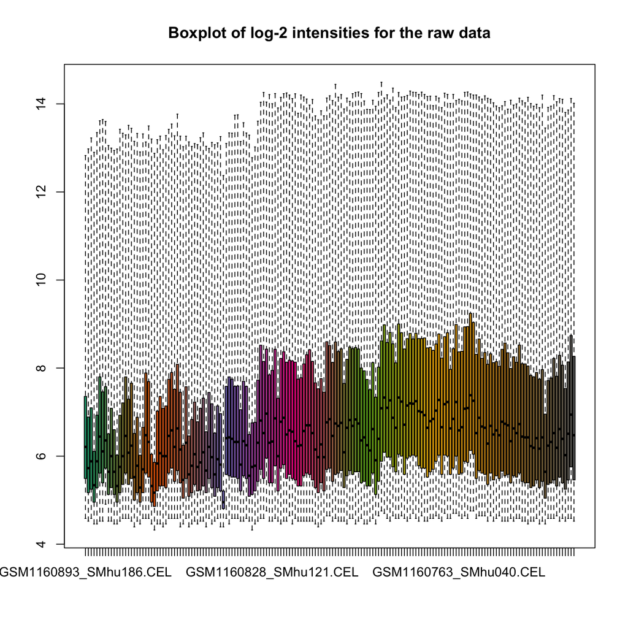

```r
oligo::boxplot(raw_data, target="core", main = "Boxplot of log-2 intensities for the raw data")
```

Raw data report

```r
#arrayQualityMetrics(expressionset = raw_data,
    #outdir = raw_data_dir,
   # force = TRUE, do.logtransform = TRUE,
   # intgroup = c("FactorValue..TREATMENT.", "Classification"))
```

## 5 Background Adjustment, calibration, summarization and annotation

### RLE (Relative Log Expression) data quality analysis

#### Backround correction

```r
palmieri_eset = oligo::rma(raw_data, target="core", normalize=FALSE)
```

```
## Background correcting
## Calculating Expression
```

```r
#Biobase::exprs(palmieri_eset)
```

#### Plotting the RLE

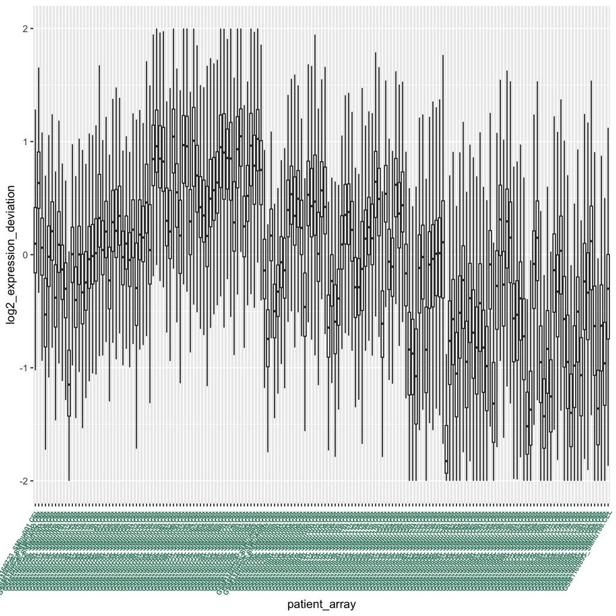

```r
row_medians_assayData <-
  Biobase::rowMedians(as.matrix(Biobase::exprs(palmieri_eset)))

RLE_data <- sweep(Biobase::exprs(palmieri_eset), 1, row_medians_assayData)

RLE_data <- as.data.frame(RLE_data)
RLE_data_gathered <-
  tidyr::gather(RLE_data, patient_array, log2_expression_deviation)

#ylim is the ylimit of the x-axis

ggplot2::ggplot(RLE_data_gathered, aes(patient_array,
                                       log2_expression_deviation)) +
  geom_boxplot(outlier.shape = NA) +
  ylim(c(-2, 2)) +
  theme(axis.text.x = element_text(colour = "aquamarine4",
                                  angle = 60, size = 6.5, hjust = 1 ,
                                  face = "bold"))
```

The above plot shows the probe intensity per chip variation with respect to median intensities We can see a couple of outliers to the left and a few to the right Very large variances exist in the data (unexpected), however, the data is not normally distributed, because the authors used a u-test, so a boxplot probably isn’t a good indicator anyway. The heatmap will probably be more useful.

#### RMA Calibration

In the original paper, they used the RMA algorithm to calibrate the data

```r
palmieri_eset_norm <- oligo::rma(raw_data, target = "core")
```

```
## Background correcting
## Normalizing
## Calculating Expression
```

#### Comparing my normalized expression values with the original paper’s

I join all the processed data into one matrix to easily compare it with my resulting expression values:

```r
for(row in 1:nrow(SDRF))
{processedfilenames=c(SDRF$Derived.Array.Data.File)}

samplepro = read.delim(file.path(processed_data_dir, processedfilenames[1]))
colnames(samplepro)=(c("ID_REF", processedfilenames[1]))

for(value in processedfilenames)
{
  processed_location = file.path(processed_data_dir, value)
  m=read.delim(processed_location)
  colnames(m)=(c("ID_REF", value))
  samplepro = left_join(samplepro, m)
}
rownames(samplepro)=c(samplepro$ID_REF)


head(samplepro)
```

```
##          ID_REF GSM1160893_sample_table.txt GSM1160892_sample_table.txt
## 7892501 7892501                     6.02006                     5.40099
## 7892502 7892502                     2.27238                     1.90819
## 7892503 7892503                     2.62475                     2.46102
## 7892504 7892504                     6.77703                     6.98153
## 7892505 7892505                     2.03101                     2.23443
## 7892506 7892506                     2.64986                     3.81618
##         GSM1160891_sample_table.txt GSM1160890_sample_table.txt
## 7892501                     5.00033                     4.18340
## 7892502                     2.49741                     4.05422
## 7892503                     2.99519                     3.00068
## 7892504                     6.48862                     6.55828
## 7892505                     2.62890                     2.10746
## 7892506                     2.36637                     3.59741
##         GSM1160889_sample_table.txt GSM1160888_sample_table.txt
```

[output cut: 587 more lines]

```r
head(Biobase::exprs(palmieri_eset_norm))
```

```
##         GSM1160893_SMhu186.CEL GSM1160892_SMhu185.CEL GSM1160891_SMhu184.CEL
## 7892501               7.071495               6.439143               6.086883
## 7892502               2.900711               2.857221               3.371663
## 7892503               3.314389               3.413294               3.865657
## 7892504               7.978189               8.029504               7.877715
## 7892505               2.520456               2.821267               3.285157
## 7892506               3.774229               5.109054               3.247749
##         GSM1160890_SMhu183.CEL GSM1160889_SMhu182.CEL GSM1160888_SMhu181.CEL
## 7892501               5.082762               6.479572               7.096420
## 7892502               4.834241               3.057574               3.516908
## 7892503               4.363048               3.722596               3.807474
## 7892504               8.069784               7.749956               7.084165
## 7892505               2.980536               2.899413               1.796751
## 7892506               4.417222               2.495495               2.925086
##         GSM1160887_SMhu180.CEL GSM1160886_SMhu179.CEL GSM1160885_SMhu178.CEL
```

[output cut: 384 more lines]

```r
#raw_probes=rownames(Biobase::exprs(palmieri_eset_norm))
```

#### Heatmap clustering analysis

Sample-to-sample heatmap:

```r
#defining the phenotype names: if it includes "non", change to non_infl, otherwise
#change to inlf
EMT_st <- ifelse(str_detect(pData
                                    (palmieri_eset_norm)$Classification,
                             "Epithelial"), "epi", "mes")

treatment_names <- ifelse(str_detect(pData
                                    (palmieri_eset_norm)$FactorValue..TREATMENT.,
                             "none"), "none", "cis")

##annotation
annotation_for_heatmap <-
  data.frame(EMT = EMT_st,  Treatment = treatment_names)

#setting rownames
row.names(annotation_for_heatmap) <- row.names(pData(palmieri_eset_norm))
```

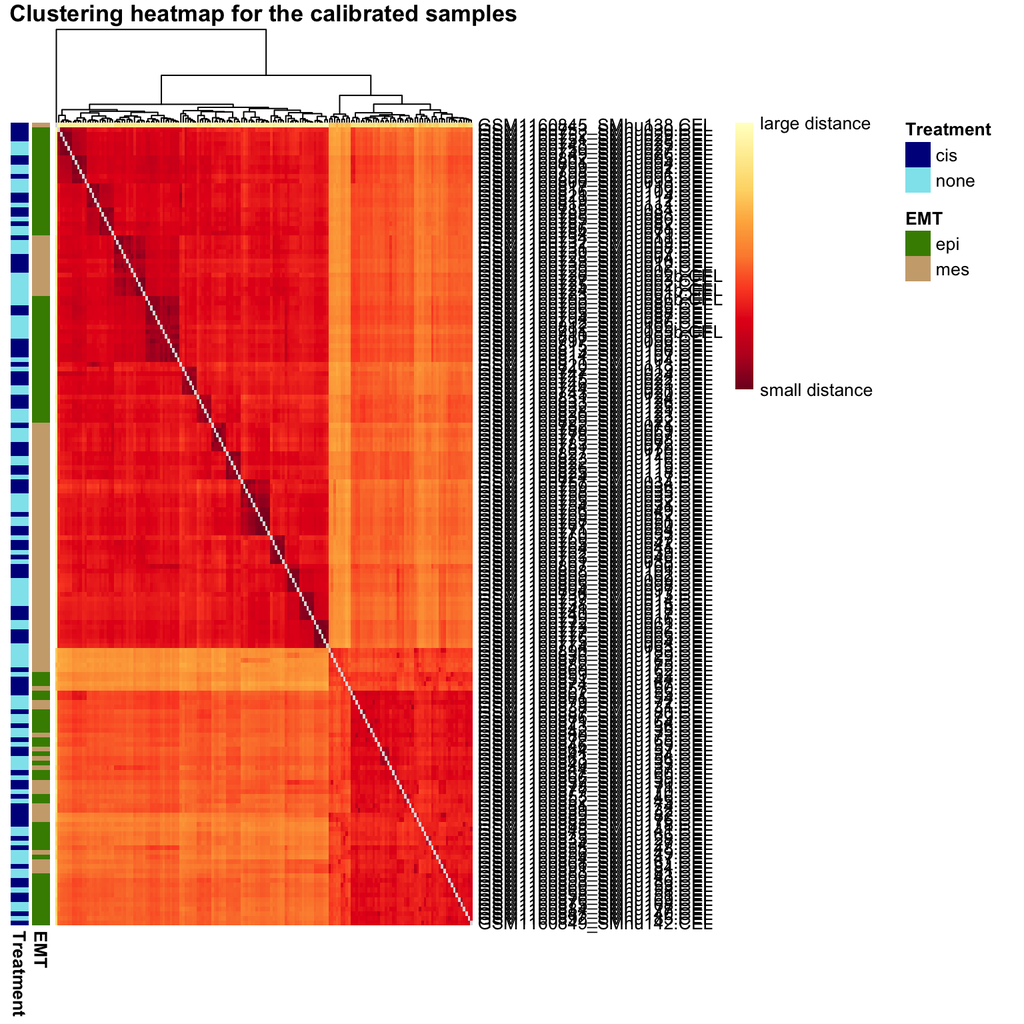

```r
exp_palmieri <- Biobase::exprs(palmieri_eset_norm)
dists <- as.matrix(dist(t(exp_palmieri), method = "manhattan"))
#manhattan |x1-x2|
#euclidian (x1-x2)^2

rownames(dists) <- row.names(pData(palmieri_eset_norm))
hmcol <- rev(colorRampPalette(RColorBrewer::brewer.pal(9, "YlOrRd"))(255))
colnames(dists) <- NULL
diag(dists) <- NA

#assigning colors for the conditions and diseases (annotation)
ann_colors <- list(
  EMT = c(epi = "chartreuse4", mes = "burlywood3"),
  Treatment = c(cis = "blue4", none = "cadetblue2")
                   )

#pheatmap: dists is the distance matrix that we calculated
pheatmap(dists, col = (hmcol),
         annotation_row = annotation_for_heatmap,
         annotation_colors = ann_colors,
         legend = TRUE,
         treeheight_row = 0,
         legend_breaks = c(min(dists, na.rm = TRUE),
                         max(dists, na.rm = TRUE)),
         legend_labels = (c("small distance", "large distance")),
         main = "Clustering heatmap for the calibrated samples")
```

#### PCA After Normalization

```r
exp_palmieri <- Biobase::exprs(palmieri_eset_norm)
```

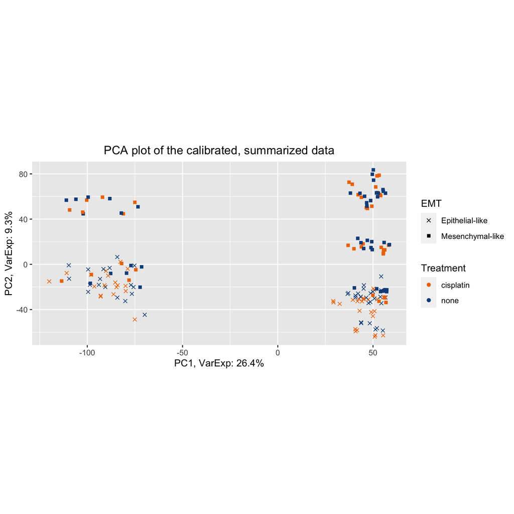

```r
PCA <- prcomp(t(exp_palmieri), scale = FALSE)

percentVar <- round(100*PCA$sdev^2/sum(PCA$sdev^2),1)
sd_ratio <- sqrt(percentVar[2] / percentVar[1])

dataGG <- data.frame(PC1 = PCA$x[,1], PC2 = PCA$x[,2],
                    EMT = pData(raw_data)$Classification,
                    Treatment = pData(raw_data)$FactorValue..TREATMENT.,
                    Source = pData(raw_data)$Source.Name)


ggplot(dataGG, aes(PC1, PC2)) +
      geom_point(aes(shape = EMT, colour = Treatment)) +
  ggtitle("PCA plot of the calibrated, summarized data") +
  xlab(paste0("PC1, VarExp: ", percentVar[1], "%")) +
  ylab(paste0("PC2, VarExp: ", percentVar[2], "%")) +
  theme(plot.title = element_text(hjust = 0.5)) +
  coord_fixed(ratio = sd_ratio) +
  scale_shape_manual(values = c(4,15)) +
  scale_color_manual(values = c("darkorange2", "dodgerblue4"))
```

The PCA now shows 5 clusters. According to the SDRF file, the experiment was done in 5 batches. The 5 clusters are probably due to the batch effect that has not been removed here.

#### Triplicate Values & Filtering Based on Variance

The authors stated that they took advantage of the triplicate data by removing potentially fragile probes with strong variations (sd>0.2) within the triplicates from the data, decreasing the total probe number from 33297 to 21329. -> 11968 probes removed

After trying it several times, and because the paper was unclear on whether it used log-transformed values or not for this step, and also because of the additional step the authors performed after RMA, I decided to go with variance>0.28 as a cutoff to get a comparable number of probe removals and not remove too many probes that may be significant.

```r
triplicate_cell_lines = c("A2008", "A2780", "C13", "CH1", "DOV13", "DOV13B", "FU-OV-1", "HeyA8", "HeyC2", "IGROV-1", "OV90", "OVCA420", "OVCA429", "OVCA433", "OVCAR-10", "OVCAR-8", "PA-1", "TYK-nu")

probes = vector()

for(value in triplicate_cell_lines)
{cell_lines=subset(SDRF2, FactorValue..CELL.LINE. == value)

cisplatin=subset(cell_lines, FactorValue..TREATMENT. == "cisplatin")
cisn=row.names(cisplatin)

cis_df = exp_palmieri[,c(cisn)]
cisrown=row.names(cis_df)
for(r in 1:nrow(cis_df))
{
  stddev=sd(cis_df[r,])
  if ((stddev*stddev)>0.28)
    {probes=c(probes, cisrown[r])}
}

control=subset(cell_lines, FactorValue..TREATMENT. == "none")
contrn=row.names(control)

contr_df = exp_palmieri[,c(contrn)]
contrown=row.names(contr_df)
for(r in 1:nrow(contr_df))
{
  stddev=sd(cis_df[r,])
  if ((stddev*stddev)>0.28)
    {probes=c(probes, contrown[r])}
}}

#probes to be removed
probes=unique(probes)
#probes
```

Below is the number of probes that will be removed.

```r
length(probes)
```

```
## [1] 11311
```

We then remove these probes from the expression set

```r
pr_rmv = rownames((Biobase::exprs(palmieri_eset_norm))) %in% probes
table(pr_rmv)
```

```
## pr_rmv
## FALSE  TRUE
## 21986 11311
```

```r
#pr_rmv
```

```r
#need to keep the false values and remove the true ones
pr_rmv=!pr_rmv
table(pr_rmv)
```

```
## pr_rmv
## FALSE  TRUE
## 11311 21986
```

```r
palmieri_manfiltered <- subset(palmieri_eset_norm, pr_rmv)
#Biobase::pData(palmieri_manfiltered)
```

```r
#head(Biobase::exprs(palmieri_manfiltered))
```

Next, the authors log-average the triplicate data into one value. We cannot average the log value of the samples, we should average the original linear value then log it to get the correct average.

```r
palmieri_manfiltered2=palmieri_manfiltered
exp_filtered = Biobase::exprs(palmieri_manfiltered2)

triplicate_cell_lines = c("A2008", "A2780", "C13", "CH1", "DOV13", "DOV13B", "FU-OV-1", "HeyA8", "HeyC2", "IGROV-1", "OV90", "OVCA420", "OVCA429", "OVCA433", "OVCAR-10", "OVCAR-8", "PA-1", "TYK-nu" )

rmvsamples=vector()

for(value in triplicate_cell_lines){

cell_lines=subset(SDRF2, FactorValue..CELL.LINE. == value)

cisplatin=subset(cell_lines, FactorValue..TREATMENT. == "cisplatin")
cisn=row.names(cisplatin)

cis_df = exp_filtered[,c(cisn)]
cisrown=row.names(cis_df)
cis_df=2^(cis_df)
rmeans=rowMeans(cis_df)
cis_df=cbind(cis_df, rmeans)
cis_df[,"rmeans"]=log2(cis_df[,"rmeans"])
cis_df[,1]=cis_df[,"rmeans"]
ciscoln=colnames(cis_df)
avgsamplen=(ciscoln[1])
avgsample=cis_df[,1, drop=FALSE]
#avgsamplen
Biobase::exprs(palmieri_manfiltered2)[,avgsamplen]=avgsample
rmvsamples=c(rmvsamples, ciscoln[2:(length(ciscoln)-1)])

control=subset(cell_lines, FactorValue..TREATMENT. == "none")
contrn=row.names(control)

contr_df = exp_filtered[,c(contrn)]
contrown=row.names(contr_df)
contr_df=2^(contr_df)
rmeans=rowMeans(contr_df)
contr_df=cbind(contr_df, rmeans)
contr_df[,"rmeans"]=log2(contr_df[,"rmeans"])
contr_df[,1]=contr_df[,"rmeans"]
contrcoln=colnames(contr_df)
avgsamplen=(contrcoln[1])
avgsample=contr_df[,1, drop=FALSE]
#avgsamplen
Biobase::exprs(palmieri_manfiltered2)[,avgsamplen]=avgsample
rmvsamples=c(rmvsamples, contrcoln[2:(length(contrcoln)-1)])

}

rmvsamples=c(rmvsamples, "GSM1160879_SMhu172.CEL")
#palmieri_manfiltered2 is the expression set with the averaged probes, still need to remove the rmvsamples from the expression set

#rmvsamples
length(rmvsamples)
```

```
## [1] 79
```

```r
totalsamples=colnames(Biobase::exprs(palmieri_manfiltered2))
keepsamples = totalsamples[! (totalsamples %in% rmvsamples)]
#keepsamples
length(keepsamples)
```

```
## [1] 92
```

```r
palmieri_f = palmieri_manfiltered2[,keepsamples]
#head(Biobase::exprs(palmieri_f))
```

```r
#Biobase::pData(palmieri_f)
```

#### Annotation of the transcript clusters

```r
anno_palmieri <- AnnotationDbi::select(hugene10sttranscriptcluster.db,
                                  keys = (featureNames(palmieri_f)),
                                  columns = c("SYMBOL", "GENENAME"),
                                  keytype = "PROBEID")
anno_palmieri <- subset(anno_palmieri, !is.na(SYMBOL))
```

```r
anno_grouped <- group_by(anno_palmieri, PROBEID)
anno_summarized <-
  dplyr::summarize(anno_grouped, no_of_matches = n_distinct(SYMBOL))
head(anno_summarized)
```

```
## # A tibble: 6 x 2
##   PROBEID no_of_matches
##   <chr>           <int>
## 1 7896740             3
## 2 7896744             4
## 3 7896759             1
## 4 7896761             1
## 5 7896779             1
## 6 7896798             1
```

```r
anno_filtered <- filter(anno_summarized, no_of_matches > 1)

head(anno_filtered)
```

```
## # A tibble: 6 x 2
##   PROBEID no_of_matches
##   <chr>           <int>
## 1 7896740             3
## 2 7896744             4
## 3 7897006             2
## 4 7897774             2
## 5 7897978             6
## 6 7897991             2
```

```r
probe_stats <- anno_filtered

nrow(probe_stats)
```

```
## [1] 1682
```

1682 probes map to multiple genes

```r
ids_to_exlude <- (featureNames(palmieri_f) %in% probe_stats$PROBEID)
# returns a true or false vector based on whether the probes have multiple matches or not
# ids to exclude are those that return true
table(ids_to_exlude)
```

```
## ids_to_exlude
## FALSE  TRUE
## 20304  1682
```

```r
palmieri_final <- subset(palmieri_f, !ids_to_exlude)

validObject(palmieri_final)
```

```
## [1] TRUE
```

As we have just excluded probe IDs from the assay data, we now have to also exclude them from the feature data anno_palmieri:

```r
head(anno_palmieri)
```

```
##     PROBEID SYMBOL                                          GENENAME
## 935 7896740  OR4F4  olfactory receptor family 4 subfamily F member 4
## 936 7896740 OR4F17 olfactory receptor family 4 subfamily F member 17
## 937 7896740  OR4F5  olfactory receptor family 4 subfamily F member 5
## 938 7896744 OR4F29 olfactory receptor family 4 subfamily F member 29
## 939 7896744  OR4F3  olfactory receptor family 4 subfamily F member 3
## 940 7896744 OR4F16 olfactory receptor family 4 subfamily F member 16
```

Recall that fData enables us to access the feature data of an expression set. Until now, no feature data whatsoever is stored in the fData(palmieri_final). Only the row names are the row names of the assay data by default, which are the PROBEIDs of the transcripts.

Therefore, we generate a column PROBEID in fData(palmieri_final) and assign the row names of fData(palmieri_final) to it:

```r
fData(palmieri_final)$PROBEID <- rownames(fData(palmieri_final))
```

Then, we left-join fData(palmieri_final)with anno_palmieri, which already contains the columns “SYMBOL” and “GENENAME”. A left-join keeps the rows and columns of the first argument and adds the corresponding column entries of the second argument:

```r
fData(palmieri_final) <- left_join(fData(palmieri_final), anno_palmieri)
#restore rownames after left_join
rownames(fData(palmieri_final)) <- fData(palmieri_final)$PROBEID

validObject(palmieri_final)
```

```
## [1] TRUE
```

```r
#head(Biobase::pData(palmieri_final))
```

```r
#head(Biobase::exprs(palmieri_final))
```

#### Getting the cisplatin-induced response of both types of cells

To detect differential responses to cisplatin between epithelial and mesenchymal-like cell lines, the transcriptomic responses to cisplatin were computed by subtracting the gene expression value of control (untreated) from that of cisplatin-treated cells.

```r
SDRF_f = Biobase::pData(palmieri_final)
expr_f = Biobase::exprs(palmieri_final)
#SDRF_f
```

```r
#head(expr_f)
```

```r
palmieri_diff = palmieri_final
SDRF_f = Biobase::pData(palmieri_diff)
expr_f = Biobase::exprs(palmieri_diff)

cell_line_names = unique(SDRF_f[,"FactorValue..CELL.LINE."])
length(cell_line_names)
```

```
## [1] 46
```

```r
keep=vector()
for(value in cell_line_names)
  {
cell_lines=subset(SDRF_f, FactorValue..CELL.LINE. == value)

cisplatin=subset(cell_lines, FactorValue..TREATMENT. == "cisplatin")
cisn=rownames(cisplatin)
cis_df = expr_f[,c(cisn), drop=FALSE]

control=subset(cell_lines, FactorValue..TREATMENT. == "none")
contrn=row.names(control)
contr_df = expr_f[,c(contrn), drop=FALSE]

cis_df=cis_df-contr_df
Biobase::exprs(palmieri_diff)[,cisn]=cis_df

keep=c(keep, cisn)
}

length(keep)
```

```
## [1] 46
```

```r
palmieri_d = palmieri_diff[,keep]
palmieri_d
```

```
## ExpressionSet (storageMode: lockedEnvironment)
## assayData: 20304 features, 46 samples
##   element names: exprs
## protocolData
##   rowNames: GSM1160893_SMhu186.CEL GSM1160891_SMhu184.CEL ...
##     GSM1160729_SMhu006.CEL (46 total)
##   varLabels: exprs dates
##   varMetadata: labelDescription channel
## phenoData
##   rowNames: GSM1160893_SMhu186.CEL GSM1160891_SMhu184.CEL ...
##     GSM1160729_SMhu006.CEL (46 total)
##   varLabels: Source.Name FactorValue..TREATMENT.
##     FactorValue..CELL.LINE. Classification
##   varMetadata: labelDescription channel
## featureData
##   featureNames: 7892509 7892514 ... 8180417 (20304 total)
##   fvarLabels: PROBEID SYMBOL GENENAME
##   fvarMetadata: labelDescription
## experimentData: use 'experimentData(object)'
## Annotation: pd.hugene.1.0.st.v1
```

palmieri_d is an expression set that contains only the difference in expression sets for each of the 46 cell lines.

```r
SDRF_f = Biobase::pData(palmieri_d)
expr_f = Biobase::exprs(palmieri_d)
```

#### Statistical Analysis

Mann-Whitney U-test was used to detect the differential transcriptomic responses between the expression changes by cisplatin treatment in epithelial-like cell line with those in mesenchymal-like cell lines with a cutoff value of P<0.01.

After checking the results table provided by the authors, I find the maximum p-value of the genes they considered to be differentially expressed, and find it to be 0.009  
So a cutoff p-value of 0.01 seems reasonable

```r
loc = file.path(suppl_dir, "differentially_expressed_genes.xls")
diffgenes_paper = read_excel(loc)
diffexpaper = diffgenes_paper[,"Probe"]
max(diffgenes_paper[,"MW.pv"])
```

```
## [1] 0.009531905
```

#### Performing the U-Test

Testing the code on a random gene In the authors’ results, the gene 8144516 has a p-value of 0.0000699600255807229 while here it has a p-value of 0.0006500818, which could also be due to the batch effect that the authors accounted for in their paper, while I did not here.

```r
genelist=rownames(expr_f)
epi_samples = rownames(subset(SDRF_f, SDRF_f[,"Classification"]=="Epithelial-like"))
mes_samples = rownames(subset(SDRF_f, SDRF_f[,"Classification"]=="Mesenchymal-like"))

epi_values = expr_f["8144516", epi_samples, drop=FALSE]
mes_values = expr_f["8144516", mes_samples, drop=FALSE]

t = wilcox.test(mes_values, epi_values, paired=FALSE)
t["p.value"]
```

```
## $p.value
## [1] 0.0006500818
```

Generating the matrix of p-values:

```r
genelist=rownames(expr_f)
epi_samples = rownames(subset(SDRF_f, SDRF_f[,"Classification"]=="Epithelial-like"))
mes_samples = rownames(subset(SDRF_f, SDRF_f[,"Classification"]=="Mesenchymal-like"))

pval_mtrx <- data.frame()

for (value in genelist){
epi_values = expr_f[value, epi_samples, drop=FALSE]
mes_values = expr_f[value, mes_samples, drop=FALSE]

t = wilcox.test(mes_values, epi_values, paired=FALSE)
wpv = t["p.value"]
v = value
vals=cbind(v, wpv)
pval_mtrx=rbind(pval_mtrx, vals)
}
```

```r
num=(which(pval_mtrx<=0.01))
length(num)
```

```
## [1] 301
```

I get 301 differentially expressed genes. The paper finds 480.